# Stochastic Volatility

This post I will simulate a Stochastic Volatility process, and estimate it using General Methods of Moments. ## The General Methods of Moments in the case of Stocastich Volatility

Consider the parameterization of the simple log-normal Stochastic Volatility (SV), assuming $\mu = 0$:

$$r_t = \sigma_t \mu_t = exp\left( \frac{W_t}{2}\right) \\
W_t = \omega + \phi W_{t-1} + \eta_{W,t}$$

where
$$\begin{pmatrix} u_t \\\ \eta_{W,t} \end{pmatrix} \overset{i.i.d.} \sim N\left(\begin{pmatrix}0 \\\ 0\end{pmatrix}, \begin{pmatrix}1 & 0\\\ 0 & \sigma_{\eta_W}^2\end{pmatrix} \right)$$

Also in this case $\theta = \left(\omega, \phi, \sigma_{\eta_{W}} \right)$. According to this model $r_t$ is stationary, and unconditional moments of all orders exist.

Andersen and Sørensen (1996) surveyed the GMM estimation of the Stochastic Volatility model. They recommend using moment condiitons for GMM estimation based on lower order moments of $r_t$, due to the higer-order moments tend to exhibit erratic finite sample behavior. They consider a GMM estimation based on subsets of 24 moments considered by Jacquier (1994). In order to describe these moments we need to first define:

$$\alpha_W = \frac{\omega}{1-\phi} \\
\beta_w^2 = \frac{\sigma_{\eta_W}^2}{1-\phi^2}$$

The moments conditions, which follow from properties of the log-normal distribution and Gaussian AR(1) model, are expressed as:

$$\mathbb{E} \left[ \left| r_t \right| \right] = \frac{2}{\pi}^{\frac{1}{2}} \mathbb{E}\left[ \sigma_t \right] \\
\mathbb{E} \left[ r_t^2 \right] = \mathbb{E} \left[ \sigma_t^2 \right] \\
\mathbb{E} \left[ \left| r_t^3 \right| \right] = 2 \sqrt{\frac{2}{\pi}} \mathbb{E}\left[ \sigma_t^3\right] \\
\mathbb{E} \left[ r_t^4 \right] = 3 \mathbb{E}\left[ \sigma_t^4\right] \\
\mathbb{E} \left[ \left| r_t r_{t-j} \right| \right] = \left( \frac{2}{\pi} \right) \mathbb{E} \left[\sigma_t \sigma_{t-j} \right], \qquad j=1:10 \\
\mathbb{E} \left[ r_t^2 r_{t-j}^2 \right] = \mathbb{E} \left[\sigma_t^2 \sigma_{t-j}^2 \right], \qquad j=1:10$$

Where for any positive integer $j$, and positive constants $p$ and $s$

$$\mathbb{E} \left[ \sigma_t^p \right] = exp \left( \frac{p \alpha_W }{2} + \frac{p^2 \beta_W^2}{8} \right) \\
\mathbb{E} \left[ \sigma_t^p \sigma_{t-j}^s\right] = \mathbb{E} \left[ \sigma_t^p \right] \mathbb{E} \left[ \sigma_t^s \right] exp \left(\frac{p s\phi^j\beta_W^2}{4} \right)$$

We set $W_t = \left(\mid r_t \mid, r_t^2, \mid r_t^3 \mid, r_t^4, \mid r_t r_{t-1} \mid , \dots , \mid r_t r_{t-10} \mid, r_t^2 r_{t-1}^2, \dots , r_t^2 r_{t-10}^2 \right)^{\prime}$, and define the $24 \times 1$ vector:

$$g(W_t, \theta_W) = \begin{pmatrix} \mid r_t \mid - \frac{2}{\pi}^{\frac{1}{2}} exp\left(\frac{\alpha_W}{2} + \frac{\beta_W^2}{8} \right) \\\ r_t^2 - \left(\alpha_W + \frac{\beta_W^2}{2} \right) \end{pmatrix} \\\
\vdots \\\
r_t^2 r_{t-10}^2 - exp\left( \alpha_W + \frac{\beta_W^2}{2} \right)^2 exp\left( \phi^{10} \beta_w^2\right)$$

Then $\mathbb{E} \left[ g\left(W_t, \theta_W \right) \right]=0$ is the population moment condition used for GMM estimation of the model parameters $\theta_W = \left( \alpha_W, \phi, \beta_W^2 \right)$. Since the elements of $W_t$ are serially correlated, the efficient weight matrix $S = avar( g_T (_0 ) ) $ must be estimated using an HAC estimator, such as:

$$S_{HAC} = \hat{\Gamma}_0 \left( \hat{\theta} \right) + 2 \sum_{j=0}^{\infty}k \left( \frac{j}{q \left( j \right)} \right) \left( \hat{\Gamma}_j \left( \hat{\theta} \right) + \hat{\Gamma}_j \left( \hat{\theta} \right) ^{\prime}\right) \\
\hat{\Gamma}_j \left( \hat{\theta} \right) = \frac{1}{T} \sum_{t=j+1}^T g_t\left(W_t, \hat{\theta} \right) g_t\left(W_{t-j}, \hat{\theta} \right)$$
for a proper kernel function $k\left( \cdot \right)$.

## Simulation

First we need to simulate the SV Process, so lets write a function which is able to do this.

```r
### Simulate SV data
SV_sim <- function(iT, dOmega, dPhi, dSigma2) {

  vY = numeric(iT)
  vU = rnorm(iT)
  vW = numeric(iT)

  vW[1] = rnorm(1, mean = dOmega/(1-dPhi), sd = sqrt(dSigma2/(1-dPhi^2)))

  for (t in 2:iT) {

    vW[t] = dOmega + dPhi * vW[t-1] + sqrt(dSigma2) * rnorm(1)

  }


  vY = exp(vW / 2) *vU

  return(list(vY = vY,
              vW = vW,
              vSigma = exp(vW / 2)))
}
```

Now we have a function which is able to simulate a SV process, lets take a look at the simulation og 10.000 observations of the process.

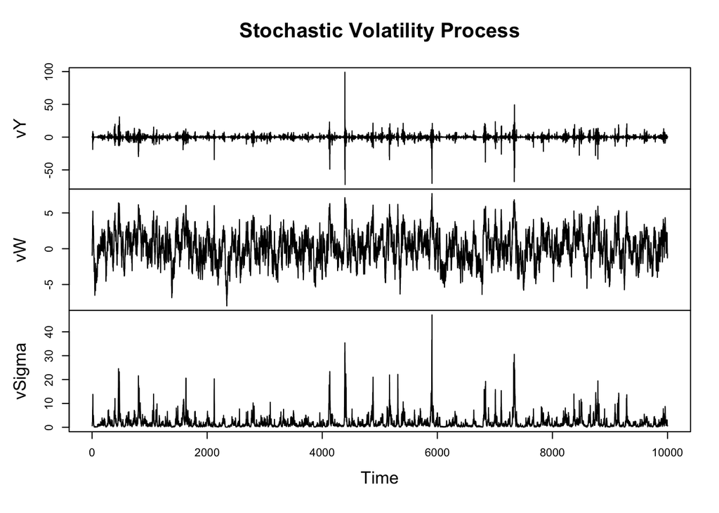

```r
iT      = 10000
dOmega  = 0.01
dPhi    = 0.95
dSigma2 = 0.5

lsim    = SV_sim(iT, dOmega, dPhi, dSigma2)

plot.ts(main = "Stochastic Volatility Process",
        col = 1,
        do.call(cbind, lsim))
```

## Estimation

$$\tag{1}
\mathbb{E} \left[ \sigma_t^p \right] = exp \left( \frac{p \alpha_W }{2} + \frac{p^2 \beta_W^2}{8} \right)$$

```r
# Function used to compute the first p moments
E.sigma_p <- function(p, dAlpha_w, dBeta2_w) {

  dE = exp(p * dAlpha_w/2 + p^2 *dBeta2_w/8)

  return(dE)
}
```

```r
E.sigma_p_sigmaj_s <- function(p, s, j, dAlpha_w, dBeta2_w, dPhi) {

  # Use the function above to calculate the first two terms of eq. (2)
  Esigma_p = E.sigma_p(p, dAlpha_w, dBeta2_w)  # E[sigma_t^p]
  Esigma_s = E.sigma_p(s, dAlpha_w, dBeta2_w)  # E[sigma_t^s]

  dE.sigma_p_sigmaj_s = Esigma_p * Esigma_s * exp(p * s *dPhi^j * dBeta2_w/4)

  return(dE.sigma_p_sigmaj_s)
}
```